# SLA or Nay?

The impact of selective licensing on rental market outcomes in Bristol

Authors

Affiliation

Levi John Wolf

University of Bristol

Alex Marsh

University of Bristol

Published

October 22, 2026

Abstract

The private rental sector is an important part of the society and economy of any nation. The sector plays a critical role in accommodating a substantial proportion of households, particularly in urban areas. In addition, it is a major source of speculative investment, both for individual and small-scale landlords and, increasingly, institutional investors. At the same time, particularly in countries with liberalised housing markets, the sector faces issues of quality, affordability and precarity. These characteristics drive intense interest in the contemporary structure and regulation of the private rental sector. As a consequence, regulation of the private rental sector is controversial. This paper examines one key regulatory tool used in England, discretionary licensing, which requires rental properties in certain areas or that fit certain characteristics to meet minimum quality standards. Research on private rental sector regulations *beyond* price controls is rare, particularly at local level. Hence, this paper seeks to build understanding about the specific short-run impacts of the adoption of discretionary licensing policies in Bristol from 2019 to 2024 using spatial causal inference techniques. We find no consistent impact on market clearing, while the rent premium for comparable properties just inside the licensing boundary narrowed after licensing was introduced: across distances from the boundary and both identification strategies, rents inside the boundary grew more slowly by between about £20 and £120 per month. This suggests that private rental sector regulation targeting minimum quality standards, such as those guaranteeing minimum energy efficiency, gas and electric safety, and other quality checks, need not raise rents or slow lettings in the short run, contrary to concerns that compliance costs would be passed on to tenants.

# Introduction

The private rental sector is a large and significant factor in many countries’ economies and societies. Rental markets define individuals’ lives, in some senses; they govern where most people in their 20s live, and increasingly they shape how and where people are able to work and start families. In the face of a global affordability crisis, many people are living much longer in private renting, whereas in previous eras they would have transitioned to other tenures, principally owner occupation. In addition, it is a major source of speculative investment, both for individual and small-scale landlords and, increasingly, institutional investors. At the same time, particularly in countries with liberalised housing markets, the sector faces issues of quality, affordability and precarity (Kemp 2025). Since the 1990s the market in England has been considered one of the most liberalised in the developed world, with tenants typically being issued with six month tenancies and landlords allowed to evict on a “no fault” basis with two months’ notice. This level of precarity places limits on the effectiveness of consumerist approaches to quality regulation: consumers are reluctant to assert rights to remedy poor quality if it means they could lose their home.

As a consequence, the regulation of the private rental sector is a significant political issue. Most analyses of rent control policies suggest that price-based rent controls have, at best, mixed effectiveness when considered as a whole across the city (Kholodilin 2024), with their negative effects on overall supply and the quality of privately-rented properties being key concerns. However, there is less agreement in the economic and policy studies literature on the impact of non-price regulation, including *minimum quality standards*, on the rental market. In part this is because there has been very limited empirical evidence, beyond the specific submarket of short-term rentals (Marsh et al. 2023). The grey literature specifically focused on licensing in the UK finds relative short-term success in the adoption of quality and licensing standards (Building Research Establishment 2010; Ministry of Housing 2019), and the policy has been argued to have benefits beyond improving housing quality (Petersen et al. 2022). Yet, other political advocacy groups argue that such positive evaluations ignore potential long-term and secondary effects of regulation of the private rental sector. In particular, there is a concern that the additional costs, both monetary and non-monetary, associated with licensing, are unnecessary; they will be passed on to tenants in higher rents or create a bureaucratic burden that will result in landlords exiting the market. This will exacerbate problems of housing accessibility in already pressured local markets.

Many of the policy models in the United Kingdom target specific segments of the private rental sector, such as rental properties with more than 5 people that comprise at least two separate households, or properties that fall into specific urban wards. This latter kind of neighborhood-level regulation has not been studied extensively (O’Toole 2023), and the evidentiary requirements for understanding regulatory impacts or, in the realm of policy, for justifying their use legally tend to be quite challenging to satisfy fully (Marsh et al. 2023; Gibb and Marsh 2022).

This paper seeks to shed light on this issue through a unique adoption pattern of neighborhood housing quality regulation policies in Bristol, England. Bristol City Council has adopted private rental sector regulations, known as *discretionary licensing* policies, that apply to specific urban wards. These policies, as discussed below, have different impacts on different types of properties, and may generate localized externalities that distort local urban rental markets. This paper seeks to identify whether, specifically, covering most of central Bristol in discretionary licensing areas from 2019 to 2024 introduced any specific short-term effects on two important private rental sector outcomes: rent levels and property turnover. This seeks to complement previous reviews of neighborhood-level rental policy with additional evidence using a novel dataset on private rental sector listings, a unique causal identification strategy, and two separate estimation strategies.

# Background: What are DLAs?

The *discretionary licensing area* (DLA) is a sub-city private rental sector regulatory tool intended to tackle specific urban social problems that are seen as relating to or otherwise influenced by issues in the housing market. The policy framework was established by the 2004 Housing Act, in which the Westminster government gave local authorities in England and Wales the power to declare selective licensing areas. The Act also introduced mandatory licensing for Houses in Multiple Occupation (HMOs) and allowed for the creation of additional licensing schemes. The Act places requirements on how and why discretionary licensing policies can be enacted and who ultimately approves the creation of a DLA. The details of these requirements have changed over time (Wilson 2023). For our purposes, discretionary licensing policies can be enacted with the aim of resolving issues such as low housing demand (i.e. urban blight), anti-social behavior, low housing supply, or poor quality housing, but also can include areas of high migration. As such, DLAs must be specific, targeted neighborhood-level regulations that seek to achieve a specific policy outcome, such as increasing housing demand as necessary to reduce urban blight, reduction in anti-social behavior ordinances or general crime, improvement in housing conditions, or reducing (or limiting the growth of) overcrowding due to in-migration. Landlords operating within a designated DLA are expected to submit to property inspections when required, meet all licensing conditions—which are set locally in the light of the problem(s) being targeted—and pay a licence fee. Operating within a DLA without a valid licence is a criminal offence. The local authority is the enforcing body.

Further, DLAs are time-limited: they are designated for five years, with the possibility of renewal. *Selective Licensing*, which applies to all properties on the private rental market within a designated area, can operate alongside *additional licensing* schemes that target specific segments of the rental market. In many UK cities, additional licensing requirements can be applied to HMOs—dwellings where tenancies involve more than two people sharing a toilet, bathroom, or kitchen—that are not covered by mandatory HMO licensing; these are typically smaller properties. Additional licensing typically involves further documentation and/or inspection requirements for the property.

In Bristol selective and additional licensing requirements have been applied across the city at different times. As a neighborhood-level rental market regulation, two city wards (Eastville and St George West) have been designated as selective licensing areas (SLAs) from 2016-2021, but a very large portion of Bristol was covered with additional licensing regulation starting in 2019 and ending in 2024. This included most of the wards in central Bristol, as shown in Figure 1. In Bristol, selective licensing requirements are inclusive of additional requirements, meaning that the introduction of *selective* licensing includes all properties that would be captured in an additional licensing scheme. We denote this as *selective+* for specificity, while additional licensing will be referred to as such. In Bristol, treatment under any DLA scheme occurs in three tranches; the first applying selective licensing to all private rental properties in two eastern wards, the second applying additional licensing across central Bristol, and the third applying selective licensing in two south Bristol wards—Bedminster and Brislington West—and extending additional licensing northward.

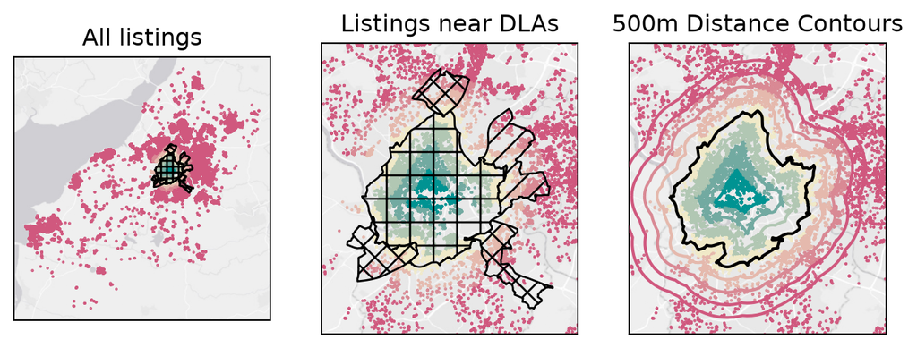

Figure 1: Map of rental listings in Bristol, as well as selective (X and //) and additional (+) licensing area boundaries.

Table 1: Bristol wards included in tranches of selective and additional licensing policy introductions.

|  | Ward | Type | Tranche | Start | End |
| --- | --- | --- | --- | --- | --- |
| 0 | Eastville | Selective+ | 1 | 2016-07-01 | 2021-06-30 |
| 1 | St George West | Selective+ | 1 | 2016-07-01 | 2021-06-30 |
| 7 | Ashley | Additional | 2 | 2019-06-10 | 2024-07-07 |
| 8 | Bishopston & Ashley Down | Additional | 2 | 2019-06-10 | 2024-07-07 |
| 4 | Central | Additional | 2 | 2019-06-10 | 2024-07-07 |
| 10 | Clifton | Additional | 2 | 2019-06-10 | 2024-07-07 |
| 11 | Clifton Down | Additional | 2 | 2019-06-10 | 2024-07-07 |
| 9 | Cotham | Additional | 2 | 2019-06-10 | 2024-07-07 |
| 5 | Easton | Additional | 2 | 2019-06-10 | 2024-07-07 |
| 6 | Hotwells & Harbourside | Additional | 2 | 2019-06-10 | 2024-07-07 |
| 3 | Lawrence Hill | Additional | 2 | 2019-06-10 | 2024-07-07 |
| 13 | Redland | Additional | 2 | 2019-06-10 | 2024-07-07 |
| 12 | Southville | Additional | 2 | 2019-06-10 | 2024-07-07 |
| 2 | Windmill Hill | Additional | 2 | 2019-06-10 | 2024-07-07 |
| 16 | Bedminster | Selective+ | 3 | 2022-04-06 | 2027-04-05 |
| 15 | Brislington West | Selective+ | 3 | 2022-04-06 | 2027-04-05 |
| 14 | Horfield | Additional | 3 | 2022-04-06 | 2027-04-05 |

## Implementation

So, what must be done if a property is regulated under selective or additional licensing designation? Typically, it requires the landlord to pay a fee of between £900 and £1500 pounds (depending on the configuration of the property and the licensing scheme), and formally record property quality and information on legally-mandated compliance, such as a gas safety certificate, an up-to-date energy performance certificate, and an electrical installation condition report. Together, these are intended to ensure that the property is of sufficient quality as to be let to tenants. Property inspections within DLAs are typically looking to identify “hazards” as defined by the Housing Health and Safety Rating System and encourage, or if necessary compel, landlords to remedy them. This is a risk-based system for identifying property defects, also introduced by the 2004 Housing Act.

Some landlords and advocacy groups argue that licensing schemes impose undue fiduciary and non-fiduciary costs on landlords. Landlords then pass these costs through to tenants, resulting in increased rent. Alternatively, individual landlords refrain from entering the private rental sector, ceding market participation to only well-resourced actors who are able to pay the licensing fees. This reduces the presence of buy-to-let activity in a licensed area, and also reduces the incentive to create new private rental properties.

These unintended effects of licensing schemes must be balanced against their intended outcomes. If these effects do exist and are severe, then we need to know about it. Alternatively, if these effects are not severe, then existing evidence suggests that these licensing schemes *do work* to improve their intended outcomes within the jurisdiction of the regulated area, with little negative externality on nearby areas. Therefore, investigating these potential unintended impacts of licensing schemes on the private rental market price levels and supply is important for understanding and assessing the use of DLAs as a policy instrument.

# Methods and Data

In order to estimate these effects precisely, we use a novel dataset of scraped property listings from a private rental sector data provider, vendored through the Urban Big Data Centre at the University of Glasgow, UK. The data ostensibly provides information on all of the private rental properties listed in the UK from 2018 to 2023. We take a subset of this data focused on Bristol post codes, and filter the data for apparent duplicates, such as listings that are made for the same property over the same time period. Thus, this provides solid data on advertised private rental properties spanning the introduction of SLAs in 2019 and 2022. This includes information on property characteristics, such as the number of bedrooms, bathrooms, and reception rooms available to rent with the listing, as well as user-contributed pictures, information on the letting agent (if applicable), full-text, short-text, and bullet-point descriptions of the listing. We take as outcomes the weekly rent charged and the duration the listing is live, and we use exogenous information about the property, such as the number of bedrooms, bathrooms, reception areas, etc. as predictors.

Occasionally, a listing’s characteristics will be modified during its lifetime. This might happen, for instance, if a one-bedroom property is listed as a two-bedroom property by mistake. These errors are rare, but we still only retain properties whose primary characteristics do not change during their listing. Alternatively, changes to a listing’s *price* can indicate that tenants are not expressing interest in the property at the initial price point. Fortunately, the data provider lists the sequence of price changes over the life of the listing (although we do not know when in the listing life the changes are made). From this information, we see that the general trend for price updates over the life of the listing is negative, suggesting landlords or agents are reducing the price in order to find a tenant willing to accept that price. Therefore, we take the *last price* on the listing as indicative of the market clearing price.[^1] We take the duration the listing was live, from first post to removal from the platform, as an indication of market turnover. Since the measure increases as the turnover slows, we call this the *staleness* of the listing. The platform itself requires the removal of listings that have gone let-agreed, so we can be reasonably sure that the listing length corresponds to time-on-market for most properties, but, some clearly-stale listings stay on the platform for over a year. Thus, we anticipate this outcome to be less straightforward to model in this application.

In effect, this forces an identification strategy that leverages spatial proximity to control for some aspects of the intangible time-varying effects of COVID-19 lockdown and stay-at-home orders. These periods are clearly evident in Figure 4, Figure 2, and Figure 3. While we can clearly see a reduction in supply across the treatment boundary in Figure 3, the later COVID-19 pandemic clearly suppresses supply further. Therefore, aggregate comparisons of rent levels or private rental sector size and turnover are likely to be hopelessly confounded by the wide-reaching changes in locational preferences induced by the COVID-19 pandemic.

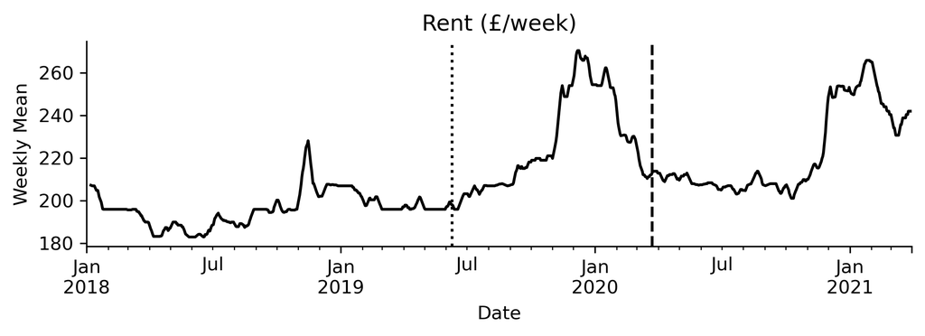

Figure 2: Evolution of the advertised rent for privately-let properties on the rental market database.

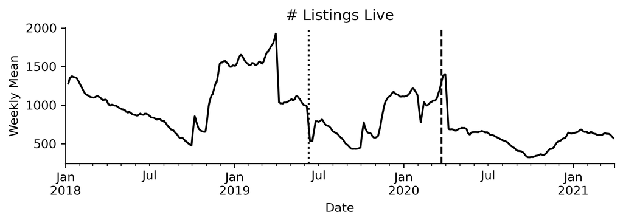

Figure 3: Typical number of listings live within a week on the private rental market database.

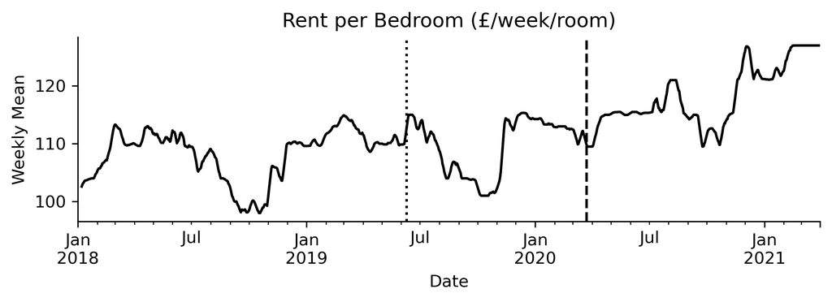

Figure 4: Rent per bedroom for listings on the private rental market database.

## Two identification strategies

First, it is useful to name the four groups of observations which allow us to identify the causal effect of licensing adoption. These are:

1. **Treated Listings**: properties inside of the discretionary licensing area put on the market after the licensing scheme was introduced. Ostensibly, landlords owning these properties must have acquired a license in order to let the flat.
2. **Pre-Treated Listings**: properties inside of the discretionary licensing area put on the market *before* the licensing scheme was introduced. Landlords of these properties would be obligated to acquire a license if the property were subsequently let privately after the licensing scheme was introduced.
3. **Substitute Listings**: properties *outside* of the discretionary licensing area put on the market after the licensing scheme was introduced. In this sense, they are *substitutes* for properties just on the other side of the licensing area boundary, and will be considered as unregulated alternatives to the licensed properties.
4. **Pre-substitute Listings**: properties *outside* of the discretionary licensing area put on the market *before* the licensing scheme was introduced. These offer substitutes to the pretreated listings.

Comparisons among these groups are fairly easy to construct. We opt for two different strategies for estimation. First, we will attempt a straightforward spatial difference in discontinuities specification. At the DLA boundary, properties are most likely to be substitutes, while far outside (or inside) the DLA boundary, properties are unlikely to be substitutes—a city center property is never going to reasonably be compared to a property in a far-out commuter community. However, a standard difference in differences application would construct such a comparison. In contrast, the SDID strategy calculates the discontinuity in outcome that exists at the DLA boundary *pre-treatment* and compares this to the boundary that exists at the DLA boundary after treatment. Formally, for outcomes $Y$ predicted by property characteristics $X$, let us denote $Y^t_i$ for an observed-treated observation $i$, while $Y^p_i$ is a pre-treated listing, $Y^s$ is a substitute listing, and $Y^{q}$ is a pre-substitute listing. Then, we calculate the difference in discontinuities as the causal effect of the policy:

$$(E[Y^t|X] - E[Y^s|X]) - (E[Y^p|X] - E[Y^q|X])$$

The first term represents the difference at the boundary post-treatment, while the second represents the difference at the boundary pre-treatment. We discuss how this is estimated later, but note for now that such a comparison is only a generic comparison between spatial groups at different time periods. We use locally-weighted models and post-hoc kernel weighting to focus the comparison local to the boundary. This acknowledges that listings are really only comparable directly near the boundary of the DLA. Imagine that the DLA ends up inflating rents through cost passthrough, as claimed by landlord interest groups. If this is the case, then properties near the boundary within the DLA should grow in rent faster than those outside the boundary. If the boundary *starts* showing that properties within the DLA are more expensive, then we expect *the difference in discontinuities* to be positive: the discontinuity between DLA and not-DLA should grow. Thus, the difference in discontinuities provides us a useful method to compare temporally across a geographical boundary.

Table 2: An example quartet, showing the main listing and its predecessor, as well as the substitute and its predecessor.

| kind | uid | Treated | In DLA? | Date | Postcode | Beds | Baths | Rent |
| --- | --- | --- | --- | --- | --- | --- | --- | --- |
| treated | db0fd646d1 | True | True | 2019-08-16 | BS31AZ | 2 | 1 | 265 |
| pretreat | 9b04dc9708 | False | True | 2018-10-12 | BS15JR | 2 | 1 | 312 |
| substitute | 257a70d7b3 | False | False | 2019-05-24 | BS148ED | 2 | 1 | 185 |
| presubstitute | 84f30e5948 | False | False | 2018-06-29 | BS148ED | 2 | 1 | 162 |

Our second estimation strategy focuses on the fact that the difference-in-discontinuity used above can be re-stated as a discontinuity-of-differences. Starting from above and regrouping the differences, we can obtain a within-property comparison.
$$(E[Y^t|X] - E[Y^s|X]) - (E[Y^p|X] - E[Y^q|X]) = (E[Y^t|X] - E[Y^p|X]) - (E[Y^s|X] - E[Y^q|X])$$

This discontinuity-of-differences reframing enables us to use a matching approach for identification. In this case, we construct a match for treated properties by finding a predecessor in the pretreated group. We also find a substitute for the treated property, and a pre-substitute predecessor listing for the substitute. All matches are constrained to have identical property characteristics, and the match overall minimizes the geographic distance. We call such a set of four a *quartet*, and one such example is shown in Table 2. The linear assignment problem for this quartet construction is as follows. Define $a_{ij}$ if treated property $i$ is assigned to predecessor $j$, $b_{ik}$ if treated property $i$ is assigned to substitute $k$, and $c_{kl}$ if substitute $k$ is assigned to pre-substitute $l$. In addition, define distance $d_{ij}$ as the relevant travel distance between listing $i$ and $j$.
$$\text{min} \sum_{ij} d_{ij}a_{ij} + \sum_{ikl} d_{ik}b_{ik} + d_{kl}c_{kl}$$
subject to
$$\sum_j a_{ij} = 1$$
$$\sum_k b_{ik} = 1$$
$$\sum_l c_{kl} \geq \sum_j b_{ik}$$
$$\sum_i a_{ij} \leq 1$$
$$\sum_i b_{ik} \leq 1$$
$$\sum_k c_{kl} \leq 1$$
$$a_{ij}$$
$$a_{ij}, b_{ik}, c_{kl} \in {0,1}$$

In practice, the problem of finding an optimal set of predecessors to each treated listing is separable from finding a substitute-presubstitute pair for each predecessor. Further, constraints on the time difference between matches can also be imposed. For this analysis, we require that substitutes occur within 90 days of the treated listing, while predecessors in pretreatment/presubstitute sets must be separated by at least 300 days.

With these matches complete, a spatial $X$-learner (Künzel et al. 2019) can then be used to model the change in outcome while addressing imbalance in the housing stock for comparisons at the boundary. In this sense, we define $\delta_i^t$ as the change in outcome experienced by treated pair focused on listing $i$, and $\delta_i^s$ as the change in outcome experienced by a substitute pair matched to listing $i$, Then, we fit separate models for inside and outside of the DLA:

$$\delta^t = f(X) + e$$
$$\delta^s = f(X) + e$$

And then use these to define a *potential outcomes model* for each region, which compares observed outcomes to counterfactuals generated from the model on the opposite side of the boundary.

$$\tau_t = \delta^t - \hat{\delta}^s = f(X) + u$$
$$\tau_s = \hat{\delta}^t - \delta^s = f(X) + u$$

Finally, we estimate a propensity score model which predicts whether a listing with characteristics $X$ is treated:

$$p(t=1) = f(X) + v$$

We recover the average treatment effect from the propensity-weighted average of the potential outcomes:

$$n^1\left(\sum_i \tau_s p + \tau_t (1-p) \right)$$

While this shifts to modelling the change within pairs, we use the same locally-weighted random forest estimators for the X-Learner submodels. The propensity score model remains a global random forest model.

### Estimation

In terms of their empirical performance, while we expect the two strategies to recover the same estimate in theory, we anticipate they will differ. We expect the $X$-learner to work well in if the housing stock is heterogeneous across the licensing area boundary, even local to it. Given rental pricing is notoriously *sticky* and experiences a unique ratcheting effect (Wang and Zhou 2000; Gallin and Verbrugge 2019), this approach also allows us to control for starting conditions more explicitly: matches over time have identical characteristics, and directly reflect prior listings against which the current listing is likely compared.

Second, we make no specific assignation of causal mechanism. That is, we cannot tell whether the DLA causes changes in the housing market through the landlord or the tenant. To illustrate, renters might view the DLA as conferring extra protections (it does not necessarily do so) or obligations on the landlord to the tenant (similarly so). If they do, any premium for regulated properties might arise simply from renters *preferring to live in licensed properties* and, as such, prefer properties marginally on the inside of the DLA line. Alternatively, any supply or turnover changes may similarly arise from altered tenant behavior. On the margin, a tenant might attempt to extend their tenancy instead of finding new accommodation if they valued its status as a licensed property. On balance, this would result in higher local rents and slower local rental markets with fewer properties being let per unit time. Even if there is only an *additional* licensing scheme in a given DLA, this effect may occur as pressure on HMO supply, driving tenants into smaller less-affordable households with fewer co-tenants.

The supply-side story is quite different, but would have similar apparent empirical effects. Given that discretionary licensing compliance is required regardless of whether or not a tenancy turns over, it would not specifically incentivise landlords to retain (or turf out) tenants. However, landlords still might view obeying the terms of the DLA as an onerous *extra cost* and thus seek to exit the rental market, since there is both a price of applying for a license, certification processes to ensure minimum quality for rented accommodation, and (potentially) an inspection by the city council during the term of the license (typically five years). This combination of fiduciary and non-fiduciary costs could indeed depress landlord participation in the rental market on the margin, which would reduce supply. In turn, this mechanism then may increase rents charged and lower market turnover. This latter justification was decisively argued by community groups during the local consultations about DLA implementation, as well as at least one UK-wide landlord advocacy group.

In order to address questions about identifying the specific mechanism by which changes affect the market, we would need more precise information about the rental market, such as within-tenancy rent changes and links to house sales to confirm rental market exits. The latter is possible, but the former is unlikely without an officially-maintained private rental sector database.

## Estimation

For the SDID models, we use characteristics like the number of bedrooms, bathrooms, reception areas, floors to predict outcomes (rent advertised, days on market) using the local random forest. In addition, the model analyzing rent levels considers listing duration as a predictor, and the model analyzing days on market can consider the advertised rent as a predictor. This is important for prediction accuracy, especially given the fact that rent declines with days on market as noted above. However, since the SDIDc does not include matches, dyadic features (like time elapsed since match) cannot be used. In contrast, the X-learner specification described above uses dyadic features and characteristics fixed before treatment: the number of bedrooms, reception rooms, and floors, whether the listing ended after the first COVID-19 lockdown, the month in which it ended, and the time elapsed since its matched predecessor, over which rent growth accrues.[^2] Then, we compare each observation’s observed change with the prediction from that observation’s *counterfactual* model, trained on observations that have a different treatment status, and fit the effect models to these differences. Quartets in which either listing’s rent more than triples or falls by more than two thirds relative to its predecessor, or in which any rent exceeds £2,000 per week, are excluded from the X-learner, since these almost always reflect monthly rents recorded as weekly or mismatched properties; this removes about 4% of listings. Finally, once the estimates are complete, we calculate the causal effect as a function of locality using a triangular kernel-weighted average of individual treatment effect estimates near the boundary. When this triangular kernel takes a bandwidth of zero, we are comparing properties *right at the DLA boundary*. As the bandwidth increases, we include observations slightly further from the boundary. This allow us to assess the sensitivity of the causal effect estimate.

# Results

In terms of describing the matching process and data characteristics, it’s useful to note a few subtotals. Around half (20,238) of the 42,838 listings are in treated areas, with the vast majority of potentially treated listings (16,198) occurring in the Bristol additional licensing area adopted from 2019 to 2024. Out of these listings in the central DLA, about half (7,637) occur after the introduction of the DLA, half again are within 1km of the boundary (4,581). Of these listings, matching properties with identical characteristics while minimizing the distance between them manages 96% efficiency: 4,380 listings are fully matched. For each treated listing, the procedure finds a predecessor inside the DLA, listed more than 300 days earlier, minimizing the total distance between treated listings and their predecessors. It then chooses each treated listing’s contemporaneous untreated substitute (listed within 90 days) and that substitute’s own predecessor (listed more than 300 days before the substitute) jointly, minimizing the summed distance from treated listing to substitute and from substitute to predecessor. No listing fills the same role in more than one quartet.

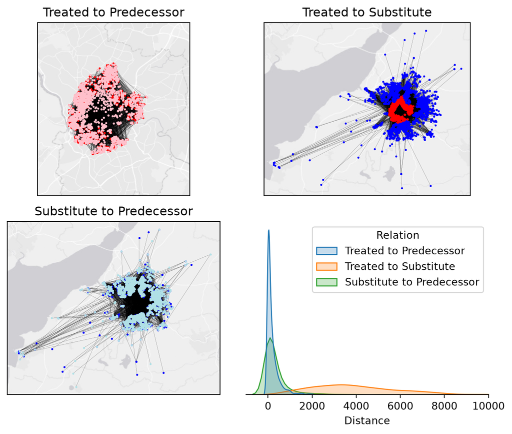

Figure 5: distribution of treated listings near the treatment boundary and their precedents, as well as substitutes and their precedents, and the distances between treated observations and their precedent, treated observations and their and substitute, and substitutes and their precedent.

Regardless, the covariates are well-balanced over quartets: distributions are shown in Figure 6, and confirm that the exogenous covariate match dimensions (beds & bathrooms) match perfectly and uncontrolled exogenous dimensions (reception count) are also undistinguishable among matches, while endogenous values (rent charged, listing time on market) differ between some quartet components. This indicates the matching has worked as intended: drawing a property at random, we couldn’t distinguish whether it was a treatment listing, a predecessor of a treatment listing, a substitute, or a predecessor of a substitute unless we looked at its *outcome* values. Parametric tests of this balance are shown in Table 3, which provides two-sample Kolmogorov-Smirnov tests across pairs of the four groups along five covariates in Figure 6, largely confirming the visual intuition.

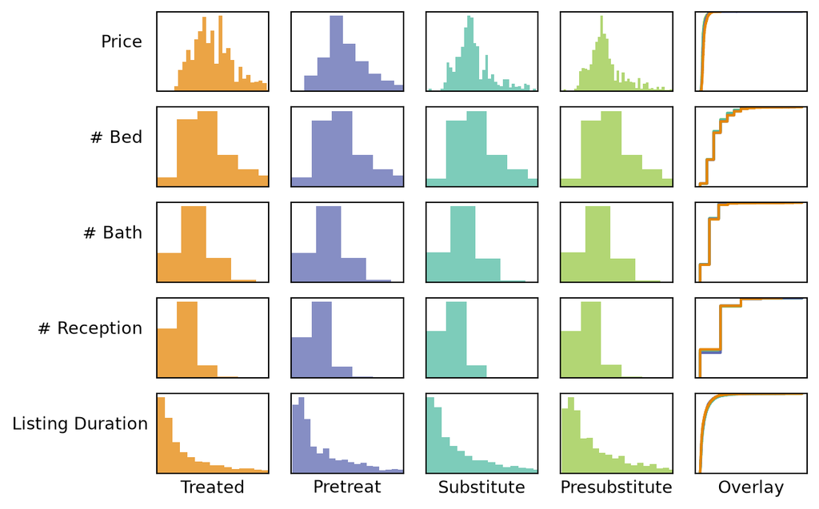

Figure 6: Distributions of relevant covariates for listings in each part of a quartet.

Table 3: Parametric pairwise tests for distribution balance using Kolmogorov-Smirnov tests with a conservative Bonferroni correction for multiple comparison. The distribution of each variate is tested across pairs within the quartet; significant results indicate that two quartet components’ distributions may differ.

|  | Variable | Quartet A | Quartet B | KS Stat | p-value | variable |
| --- | --- | --- | --- | --- | --- | --- |
| 0 | price_last | treated | pretreat | 0.11 | 0.0 | Price |
| 1 | price_last | treated | substitute | 0.25 | 0.0 | Price |
| 2 | price_last | treated | presubstitute | 0.31 | 0.0 | Price |
| 3 | price_last | pretreat | substitute | 0.15 | 0.0 | Price |
| 4 | price_last | pretreat | presubstitute | 0.22 | 0.0 | Price |
| 5 | price_last | substitute | presubstitute | 0.09 | 0.0 | Price |
| 25 | listing_duration_ | treated | substitute | 0.05 | 0.0 | Listing Duration |
| 26 | listing_duration_ | treated | presubstitute | 0.08 | 0.0 | Listing Duration |
| 28 | listing_duration_ | pretreat | presubstitute | 0.06 | 0.0 | Listing Duration |

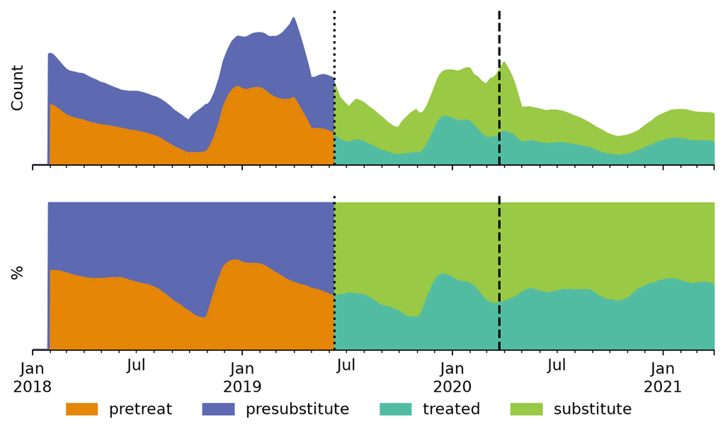

Figure 7: The composition of the panel matches across the data.

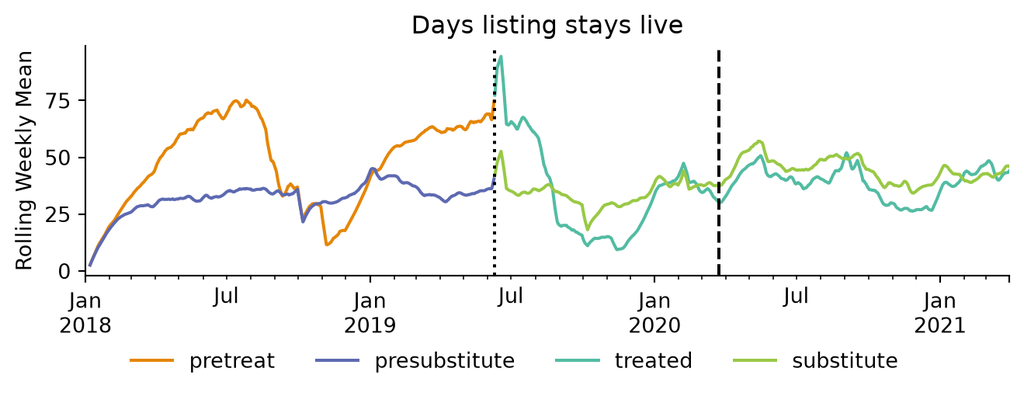

Figure 8: Typical length of time listings are live, calculated as the average duration of listings live within a week of the given date.

### Spatial Difference in Discontinuity

In terms of the spatial difference in discontinuity model, we can from Figure 9 see the models are passable at predicting the price across treatment boundaries, but the duration predictions are fairly poor. This comports with our expectations from first principles about what “staleness” represents in this data. Still, the price predictions are passable here, given the heterogeneity of the market and the relatively limited information used to make predictions.

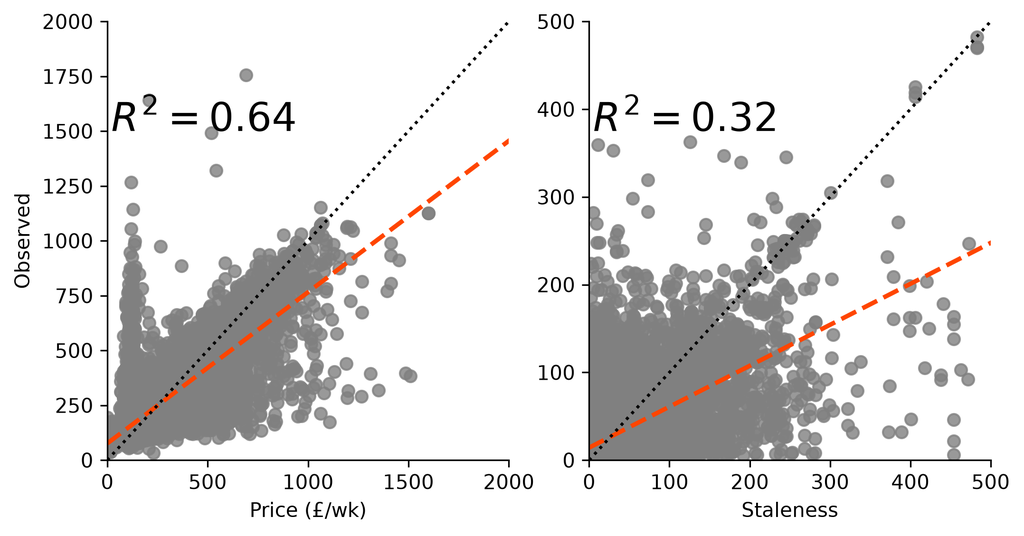

Figure 9: Spatial Difference in Discontinuity residuals, pooled across treatment status

Table 4: Estimated ATE and group discontinuity differences for the SDID specification

|  | level_0 | gross | gross.1 | weighted | weighted.1 |
| --- | --- | --- | --- | --- | --- |
| 0 | outcome | duration | price | duration | price |
| 1 | ATE | 2.5183 | 0.9359 | 3.6162 | -15.174 |

Before DLA introduction, models trained inside the DLA predicted higher rents than models trained outside it for the same properties near the boundary: the pre-treatment discontinuity is about £38 per week, and about 2 days for listing duration. This initial discontinuity is a straightforward comparison of the local rents near the boundary pre-treatment. After the DLA was introduced, models trained inside the DLA still predicted higher rents, but by less: the post-treatment discontinuity is about £23. The change in the discontinuity is therefore about −£15 per week (bottom row, right pane of Figure 10): the premium for properties just inside the boundary narrowed after the DLA came into force, suggesting rents on the city-center side grew more slowly than rents on the city-periphery side. Over the entire regulated area (top row, right pane), the change is negligible (about £1 per week), but this comparison includes very central properties for which outlying rentals are not really substitutes. For listing duration, the changes are small: about 2.5 days overall and 3.6 days close to the boundary, the latter not distinguishable from zero.

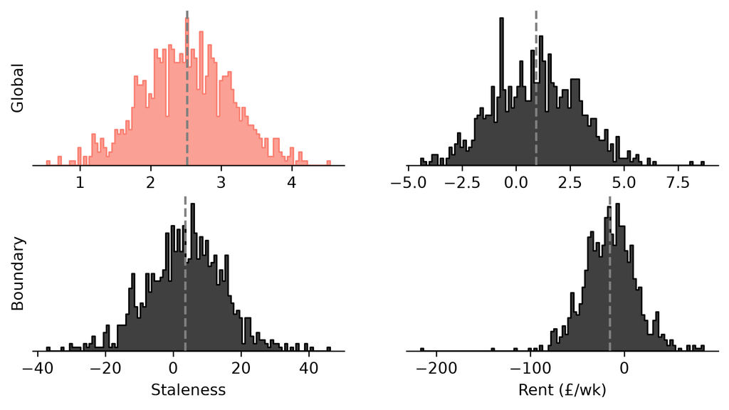

Figure 10: Average Treatment Effect (ATE)s of DLA introduction and distribution of bootstrapped ATEs to indicate variability.

### $X$-learner Results

The matching $X$-learner analysis largely agrees with the SDIDc analysis. As anticipated, predicting specific changes in rent levels within property pairs is much harder than predicting general rent levels in a given cross-section. Considering model adequacy in Figure 11, changes in both outcomes are poorly predicted by property characteristics alone. The predictions are weakly correlated with the observed changes ($r$ of about 0.21 to 0.28 for rent and 0.03 to 0.17 for listing duration), but they vary more than a relationship warrants, so their out-of-sample $R^2$ is below zero: they are no more accurate than predicting the average change for every listing.

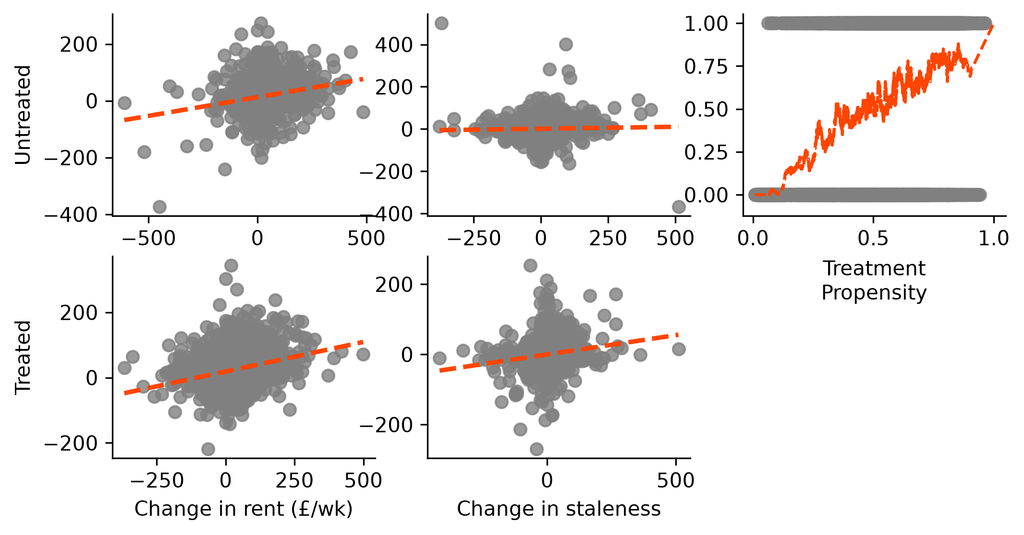

Figure 11: Model adequacy plots for the X-Learner identification strategy. Changes in both outcomes are poorly predicted by property characteristics alone.

Finally, we consider the causal effect estimates in Figure 12 and Table 5. Across all quartets, rents in regulated areas grew slightly less than outside them: the treatment effect is about −£2.30 per week, even after taking into account starting rent levels and price fluctuations due to COVID-19. This effect is distinguishable from zero in both the bootstrap and the propensity-shuffled bootstrap.[^3] Because most quartets pair a treated listing with a distant substitute, Table 6 also weights quartets by a triangular kernel in the distance between the treated listing and its substitute, mirroring the SDID’s weighting by distance to the boundary. The estimate is more negative when the comparison is more local: about −£4.60 per week with a 3 km bandwidth, −£6.10 with 2 km, and −£5.40 (95% interval −£10.60 to −£0.60) with 1 km. For clearing speed, listings within the DLA stay live about 1.6 days less on average, which is distinguishable from zero; the distance-weighted estimates are similar, about 1.8 to 2.6 days less, although the 1 km estimate is not distinguishable from zero. The effect is small, is not distinguishable from zero near the boundary, and is not matched by the SDID duration estimate, so we find no consistent impact of the DLA on how quickly properties were let.

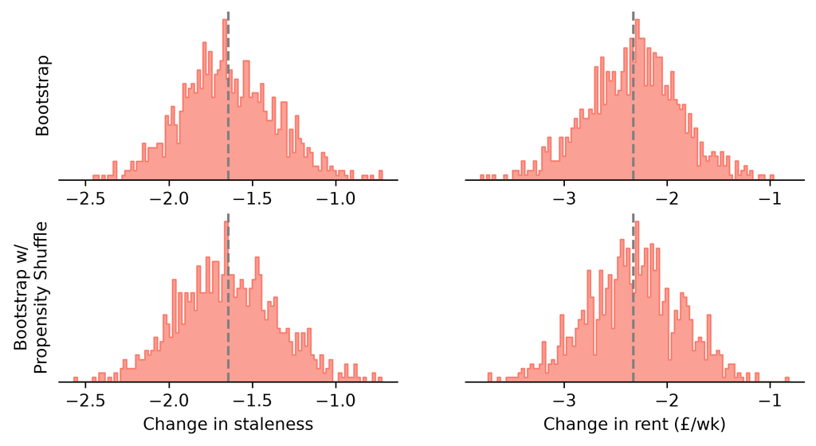

Figure 12: Similar to Figure 10, this shows the distribution of bootstrapped ATEs, alongside the estimated effect. Propensity-shuffled estimates analyse the possibility that the propensity model is misspecified by simply shuffling the propensity scores assigned by the model at random.

Table 5: X-learner estimated ATE

|  |  | Price | Duration |
| --- | --- | --- | --- |
| 0 | ATE | -2.33 | -1.64 |

Table 6: X-learner estimated ATE with quartets weighted by a triangular kernel in the distance between the treated listing and its substitute, with 95% bootstrap intervals. All rows exclude treated listings without a matched substitute, so the unweighted row differs slightly from Table 5.

| Bandwidth | Quartets | Rent | Rent (low) | Rent (high) | Duration | Duration (low) | Duration (high) |
| --- | --- | --- | --- | --- | --- | --- | --- |
| unweighted | 4223 | -1.97 | -2.78 | -1.13 | -1.47 | -2.02 | -0.94 |
| 3 km | 1505 | -4.62 | -6.21 | -2.87 | -1.84 | -2.84 | -0.72 |
| 2 km | 705 | -6.11 | -8.79 | -3.42 | -2.04 | -3.59 | -0.53 |
| 1 km | 173 | -5.44 | -10.59 | -0.56 | -2.58 | -6.32 | 1.22 |

### Comparing the estimates

The SDID and X-learner estimates differ in magnitude, in part because they compare different listings. The SDID compares listings on either side of the boundary directly, while most X-learner quartets pair a treated listing with a substitute several kilometres away (median match distance is 3.7 km; only 4% within 1 km). Figure 13 shows both estimates as their comparisons are restricted to listings closer to the boundary. Further, as noted in Figure 13, we can see that focusing the comparison on the boundary is important. The SDIDc analysis provides consistently negative, larger-magnitude estimates of the rent slowdown in the city center. As we average over listings even a reasonable distance from the boundary (e.g. 200m), the effect becomes (and then remains) significant and negative, agreeing in direction with the X-Learner estimate. The X-Learner estimate, in contrast, is largely consistent as further-and-further matches are included. In contrast, the staleness/days on market estimate is highly variable, with the SDIDc estimate changing sign twice and the X-Learner once. Thus, it seems more credible that the rent estimate is significant, negative, and reflects (conservatively) between a £20 to £120 per month *decrease* in the rent gap at the boundary, while clearing time remains unchanged.

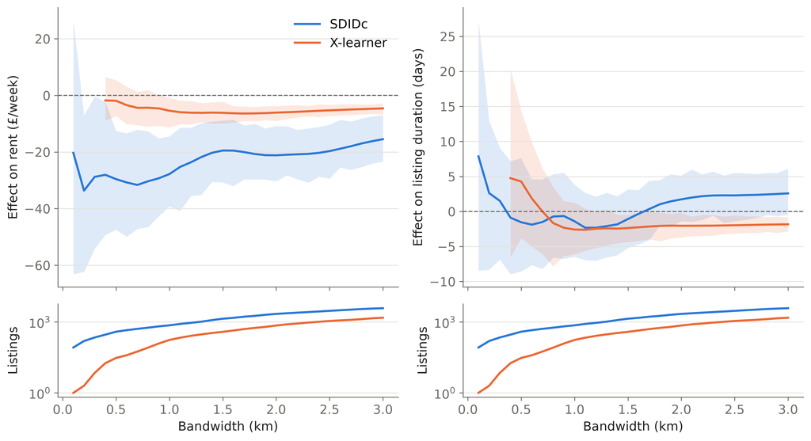

Figure 13: SDIDc and X-learner estimates of the effect of the DLA on rent and listing duration by bandwidth, with 95% bootstrap intervals. The SDIDc bandwidth is in distance to the boundary; the X-learner bandwidth is in distance between the treated listing and its substitute. Lower panels show the number of listings outside the boundary (SDIDc) and of quartets (X-learner) within each bandwidth.

# Discussion and Conclusion

Discretionary licensing is an important tool for local government in regulating the private rental sector in England and Wales. The use of these policies must generally target concerns about poor housing quality, urban market failure, or anti-social behavior, but some argue that the use of selective and additional licensing authority introduces unnecessary additional costs that get passed off onto tenants through higher rents. In addition, these policies have been suggested to drive landlords out of the rental market.

The analysis here provides little evidence that the introduction of discretionary licensing policies in central Bristol wards starting in 2019 reduced supply or raised rents in the short run. Before the DLA, properties just inside its boundary commanded a rent premium over comparable properties just outside; after its introduction, this premium narrowed. Across distances from the boundary, the narrowing is about £15 to £30 per week in the spatial difference in discontinuity and about £5 to £6 per week in the X-learner, or between about £20 and £120 per month. Rental market clearing shows no consistent change: near the boundary, neither estimate of the DLA’s effect on listing staleness is distinguishable from zero, and the X-learner’s estimate that listings let about 1.6 days faster across all quartets is not matched by the spatial difference in discontinuity. This does not support the concern that licensing costs are passed through to tenants as higher rents, at least over this period. If licensing improved quality, or if tenants treated a licence as a signal of quality, rents inside the DLA would be expected to rise relative to those outside; that they did not suggests that compliance costs were largely absorbed by landlords, or that licensing curbed rents at the top of the local market.

Identifying these short-run changes is important for building longer-term understanding of the efficacy of these minimum standards-type rental regulations. Indeed, while the impact of price controls on housing quality are well understood for rent *control*, the effects of these kinds of minimum standard or inspection-type licensing strategies are not as well understood. Thus, the next step is to investigate whether this evidence of a narrowing rent premium within DLA boundaries, with no consistent change in clearing speed, is replicated elsewhere.

# Acknowledgements

Thank you to the Urban Big Data Center for providing the data used in this analysis and the Bristol City Council for commissioning the work. This is part of an ESRC-funded Impact Acceleration project through the University of Bristol, *Bristol City Council Living Rent Commission: Understanding the Local Structure of Affordable Housing*, and further funding by PolicyBristol from the Research England QR Policy Support Fund (QR PSF) 2022-24. Throughout, basemap tiles are © Esri (World Gray Canvas; sources: Esri, DeLorme, and NAVTEQ).

## References

Abadie, Alberto, and Guido W Imbens. 2006. “Large Sample Properties of Matching Estimators for Average Treatment Effects.” *Econometrica* 74 (1): 235–67.

Building Research Establishment. 2010. *Evaluating the Impact of HMO and Selective Licensing*. Department of Communities; Local Government.

Gallin, Joshua, and Randal J. Verbrugge. 2019. “A Theory of Sticky Rents: Search and Bargaining with Incomplete Information.” *Journal of Economic Theory* 183: 478–519. https://doi.org/10.1016/j.jet.2019.06.003.

Georganos, Stefanos, Tais Grippa, Assane Niang Gadiaga, et al. 2019. “Geographical Random Forests: A Spatial Extension of the Random Forest Algorithm to Address Spatial Heterogeneity in Remote Sensing and Population Modelling.” *Geocarto International* 36 (2): 121–36. https://doi.org/10.1080/10106049.2019.1595177.

Gibb, Ken, and Alex Marsh. 2022. *Rent Control: Principles, Practicalities, and International Experience*. UK Collaborative Centre for Housing Evidence.

Kemp, P., ed. 2025. *Private Renting in Advanced Economies*. Bristol University Press.

Kholodilin, Konstantin A. 2024. “Rent Control Effects Through the Lens of Empirical Research: An Almost Complete Review of the Literature.” *Journal of Housing Economics* 63 (March): 101983. https://doi.org/10.1016/j.jhe.2024.101983.

Künzel, Sören R., Jasjeet S. Sekhon, Peter J. Bickel, and Bin Yu. 2019. “Metalearners for Estimating Heterogeneous Treatment Effects Using Machine Learning.” *Proceedings of the National Academy of Sciences* 116 (10): 4156–65. https://doi.org/10.1073/pnas.1804597116.

Marsh, A., K. Gibb, N. Harrington, and B. Smith. 2023. *The Impact of Regulatory Reform on the Private Rented Sector*. UK Collaborative Centre for Housing Evidence.

Martin Fleischmann, James Gaboardi, Ashish Raj, Shubham Singh, Jigyasa, and GA07. 2026. *Pysal/Gwlearn: V0.2.0*. Zenodo. https://doi.org/10.5281/ZENODO.20066719.

Ministry of Housing, & Local Government, Communities. 2019. *An Independent Review of the Use and Effectiveness of Selective Licensing*. Edited by Scott Lawrence and Peter Wilson.

O’Toole, Conor. 2023. “Exploring Rent Pressure Zones: Ireland’s Recent Rent Control Regime.” *International Journal of Housing Policy* 23 (4): 712–33. https://doi.org/10.1080/19491247.2022.2155338.

Petersen, Jakob, Alexandros Alexiou, David Brewerton, et al. 2022. “Impact of Selective Licensing Schemes for Private Rental Housing on Mental Health and Social Outcomes in Greater London, England: A Natural Experiment Study.” *BMJ Open* 12 (12): e065747. https://doi.org/10.1136/bmjopen-2022-065747.

Service, Deposit Protection. 2025. https://www.depositprotection.com/news-insights/average-tenancy-now-more-than-1000-days.

Spell, Lindsay, and Mark Perry. n.d. *More Exurban Communities Now Among Nation’s Fastest Growing Places*. https://www.census.gov/library/stories/2024/05/exurbs-city-population.html.

Wang, Ko, and Yuqing Zhou. 2000. “Overbuilding: A Game‐theoretic Approach.” *Real Estate Economics* 28 (3): 493–522. https://doi.org/10.1111/1540-6229.00810.

Wilson, W. 2023. *Selective Licensing of Private Rented Housing in England and Wales*. Research Briefing No. CBP04634. House of Commons Library.